# Jupyter Notebooks

[figure not shown]

### Introduction

*What is a Jupyter Notebook?*  
Well, this is...  
The document you are reading was created in the Jupyter Notebook IDE (Integrated Development Environment). Jupyter Notebooks allow you to program and markup your work all in one location, and that is just skimming the surface of what they have to offer.

As it states on the official Jupyter Notebook website,

> "The Jupyter Notebook is a web application that allows you to create and share documents that contain live code, equations, visualizations and explanatory text. Uses include: data cleaning and transformation, numerical simulation, statistical modeling, machine learning and much more."  
> -[jupyter.org](http://jupyter.org/)

For example, say I wanted to create a Python program to display "Hello World", and then share that program with my friends. In a Jupyter Notebook, it would simply look like this!

```python
print("Hello World")
```

```
Hello World
```

### Getting Up and Running

Want to make a Jupyter Notebook of your own? Just follow [this link](https://try.jupyter.org/), and click **new** Python 3 from the dropdown menu as shown in the following image!

##### Jupyter Dashboard

[figure not shown]

Once you select Python 3 from the dropdown menu, you should see a screen like the one in the following image.

##### Jupyter IDE

[figure not shown]

All of your coding is done in Jupyter Notebook cells. A **code** cell will parse Python 3 code, and a **markdown** cell will parse HTML code. To switch to markdown, simply select it from the dropdown menu as shown in the following image.

Hotkey to switch to markdown: esc + m

##### Cell Menu

[figure not shown]

For this tutorial, we will work with:

Code(Python 3)

Markdown(HTML)

In addition to formatting your cell, some other helpful buttons are:

[figure not shown]

Add New Cell

[figure not shown]

Delete Cell

[figure not shown]

Move Cell

[figure not shown]

Run/Stop Cell

Hotkey to run cell: shift + enter

### HTML

Let's learn some basic front end web design...  
Start by selecting markdown from the dropdown menu we just looked at. When you click on the cell, you will notice that the color changed from blue, to green as shown in the following image.

[figure not shown]

To program in html, you first need to specify what **HTML tag** you are going to be creating.

**Paragraph**

As an example, a <p>Paragraph</p> tag, will format anything between <p></p> as a paragraph.

##### Paragraph Tag Example

*Input*

<p> "If you try and take a cat apart to see how it works, the first thing you have on your hands is a nonworking cat. Life is a level of complexity that almost lies outside our vision; it is so far beyond anything we have any means of understanding that we just think of it as a different class of object, a different class of matter; 'life', something that had a mysterious essence about it, was God given, and that's the only explanation we had. The bombshell comes in 1859 when Darwin publishes On the Origin of Species. It takes a long time before we really get to grips with this and begin to understand it, because not only does it seem incredible and thoroughly demeaning to us, but it's yet another shock to our system to discover that not only are we not the centre of the Universe and we're not made by anything, but we started out as some kind of slime and got to where we are via being a monkey. It just doesn't read well." </p>

-Douglas Adams

*Output*

"If you try and take a cat apart to see how it works, the first thing you have on your hands is a nonworking cat. Life is a level of complexity that almost lies outside our vision; it is so far beyond anything we have any means of understanding that we just think of it as a different class of object, a different class of matter; 'life', something that had a mysterious essence about it, was God given, and that's the only explanation we had. The bombshell comes in 1859 when Darwin publishes On the Origin of Species. It takes a long time before we really get to grips with this and begin to understand it, because not only does it seem incredible and thoroughly demeaning to us, but it's yet another shock to our system to discover that not only are we not the centre of the Universe and we're not made by anything, but we started out as some kind of slime and got to where we are via being a monkey. It just doesn't read well."

-Douglas Adams

**Headings**

To create titles and headings in HTML, you use <h1>Header</h1> tags.

##### Header Tag Examples

Cell Input

Cell Output

<h1>Input</h1>

# Output

<h2>Input</h2>

## Output

<h3>Input</h3>

### Output

<h4>Input</h4>

#### Output

<h5>Input</h5>

##### Output

**Lists**

Lists and bullet points are created in HTML with the <li>List</li> tag.

##### List Tag Example

*Input*

<li>list item 1</li>  
<li>list item 2</li>  
<li>list item 3</li>

*Output*

list item 1

list item 2

list item 3

**Tables**

Another useful way to display data in a Jupyter Notebook is with a table. Tables are created in HTML with the <table>Table</table> tag.

##### Table Tag Example

*Input*

<table>  
<tr>  
<th> Header 1 </th>  
<th> Header 2 </th>  
</tr>  
<tr>  
<td> Data 1 </td>  
<td> Data 2 </td>  
</tr>  
<tr>  
<td> Other Data 1 </td>  
<td> Other Data 2 </td>  
</tr>  
</table>

*Output*

| Header 1 | Header 2 |
| --- | --- |
| Data 1 | Data 2 |
| Other Data 1 | Other Data 2 |

**Quotes**

Another useful tag that Jupyter provides us is the <blockquote>Blockquote</blockquote> tag.

##### Blockquote Tag Example

*Input*

<blockquote>  
"Imagine a puddle waking up one morning and thinking, "This is an interesting world I find myself in — an interesting hole I find myself in — fits me rather neatly, doesn't it? In fact it fits me staggeringly well, may have been made to have me in it!" This is such a powerful idea that as the sun rises in the sky and the air heats up and as, gradually, the puddle gets smaller and smaller, it's still frantically hanging on to the notion that everything's going to be alright, because this world was meant to have him in it, was built to have him in it; so the moment he disappears catches him rather by surprise. I think this may be something we need to be on the watch out for. We all know that at some point in the future the Universe will come to an end and at some other point, considerably in advance from that but still not immediately pressing, the sun will explode. We feel there's plenty of time to worry about that, but on the other hand that's a very dangerous thing to say."  
<br>  
<br>  
-Douglas Adams  
</blockquote>

*Output*

> "Imagine a puddle waking up one morning and thinking, "This is an interesting world I find myself in — an interesting hole I find myself in — fits me rather neatly, doesn't it? In fact it fits me staggeringly well, may have been made to have me in it!" This is such a powerful idea that as the sun rises in the sky and the air heats up and as, gradually, the puddle gets smaller and smaller, it's still frantically hanging on to the notion that everything's going to be alright, because this world was meant to have him in it, was built to have him in it; so the moment he disappears catches him rather by surprise. I think this may be something we need to be on the watch out for. We all know that at some point in the future the Universe will come to an end and at some other point, considerably in advance from that but still not immediately pressing, the sun will explode. We feel there's plenty of time to worry about that, but on the other hand that's a very dangerous thing to say."  
> -Douglas Adams

As is apparent from the above cell output, blockquotes are useful for quoting large amounts of text. Also, you may have noticed that I included two <br> tags in the quote. <br> tags simply add a new line within your html.

**Formatting**

Some common tags used for formatting text are...

##### Formatting Tag Examples

| Cell Input | Cell Output |
| --- | --- |
| <b>Bold</b> | **Bold** |
| <i>Italics</i> | *Italics* |
| <u>Underline</u> | Underline |

**Hyperlinks**

Hyperlinks, or <a>Anchor</a> tags, take a special property called href that provides a reference to a "hyperlink".

##### Anchor Tag Example

*Input*

<a href="http://www.w3schools.com">Link to W3 Schools</a>

*Output*  
[Link to W3 Schools](http://www.w3schools.com/)

**Wrapping Up HTML**

[W3 Schools](http://www.w3schools.com) is a great way to learn about HTML. At this point you should experiment on your own with some HTML tags. Some things to explore would be image tags, video tags, and CSS.

### Python

The rest of this tutorial will be an example Python project that illustrates some basic functionality of Jupyter Notebooks. If you would like to learn more about Python, feel free to check out some of my other notebooks here.

##### Problem Statement

Ask a user for three test scores and calculate the average score and grade.

Create a flowchart for your program.

Implement the program, and display both the test scores and grades, and the average score and grade.

Create a bar graph of the three test scores.

##### HTML + CSS Flowchart Example

<div style="float:left;">  
<center>  
<div style="border-style:solid;  
border-radius:50%;  
padding:10px;  
width:50%;" >  
Start  
</div>  
</center>  
<center>  
<span style="font-size:50px">  
&#8595;  
</span>  
</center>  
<center>  
<div style="width: 100px;  
height: 50px;  
transform: skew(-15deg);  
border-style:solid;" >  
Get input for test scores  
</div>  
</center>  
<center>  
<span style="font-size:50px">  
&#8595;  
</span>  
</center>  
<center>  
<div style="width: 100px;  
height: 50px;  
border-style:solid;" >  
Calculate average  
</div>  
</center>  
<center>  
<span style="font-size:50px">  
&#8595;  
</span>  
</center>  
<center>  
<div style="width: 200px;  
height: 140px;  
padding: 20px;" >  
<div style="border-style: solid;  
height: 100px;  
width: 100px;  
transform:rotate(45deg);  
margin:auto;  
padding:25px;" >  
<center style="transform:rotate(-45deg);">  
Decide grade  
</center>  
</div>  
</div>  
</center>  
<center>  
<span style="font-size:50px">  
&#8595;  
</span>  
</center>  
<center>  
<div style="width: 100px;  
height: 75px;  
transform: skew(-15deg);  
border-style:solid;" >  
Output test scores and grades  
</div>  
</center>  
<center>  
<span style="font-size:50px">  
&#8595;  
</span>  
</center>  
<center>  
<div style="border-style:solid;  
border-radius:50%;  
padding:10px;  
width:50%;" >  
End  
</div>  
</center>  
</div>

Start

↓

Get input for test scores

↓

Calculate average

↓

Decide grade

↓

Output test scores and grades

↓

End

##### Python Program Example

```python
#Input
testOne = float(input("Please provide a grade for test 1:"))
testTwo = float(input("Please provide a grade for test 2:"))
testThree = float(input("Please provide a grade for test 3:"))

testAverage = 0.0

#getAverage
testAverage = (testOne+testTwo+testThree)/3

#getGrade
def getGrade(testAverage):
    if testAverage <= 100 and testAverage >=90:
        grade = "A"
    elif testAverage < 90 and testAverage >=80:
        grade = "B"
    elif testAverage < 80 and testAverage >=70:
        grade = "C"
    elif testAverage < 70 and testAverage >=60:
        grade = "D"
    else:
        grade = "F"
    return grade

#Output
print("\nTest\t\t\tLetter Grade")
print(format(testOne,"0.2f"),"\t\t\t",getGrade(testOne))
print(format(testTwo,"0.2f"),"\t\t\t",getGrade(testTwo))
print(format(testThree,"0.2f"),"\t\t\t",getGrade(testThree))
print("\nAverage\t\t\tLetter Grade")
print(format(testAverage,"0.2f"),"\t\t\t",getGrade(testAverage))
```

```
Please provide a grade for test 1:70
Please provide a grade for test 2:80
Please provide a grade for test 3:90

Test			Letter Grade
70.00 			 C
80.00 			 B
90.00 			 A

Average			Letter Grade
80.00 			 B
```

##### Example Graph

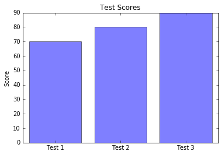

```python
%pylab inline
import numpy as np
import matplotlib.pyplot as plt

tests = ('Test 1', 'Test 2', 'Test 3')
y_pos = np.arange(len(tests))
scores = [testOne,testTwo,testThree]

plt.bar(y_pos, scores, align='center', alpha=0.5)
plt.xticks(y_pos, tests)
plt.ylabel('Score')
plt.title('Test Scores')

plt.show()
```

### Python + HTML

Not only can we seperately code HTML and Python, but we can combine the two! As an example, say we wanted to print "Hello World" in an h1 tag. This is possible by hooking into Jupyter's own display library!

##### Displaying HTML With Python

```python
from IPython.core.display import display, HTML
display(HTML('<h1>Hello, world!</h1>'))
```

Hello, world!

Jupyter provides us with an incredible level of control over a Notebook. We can even simulate a GUI by clearing the output (this example is a tad advanced, so do not feel discouraged if it makes no sense).

```python
from IPython.core.display import display, HTML, clear_output
from time import sleep
def getName():
    display(HTML('<h1>What is your name?</h1>'))
    name = input()
    clear_output()
    return name
def showGreeting(name):
    nameString = '<h1>Hello, '+name+'!</h1>'
    display(HTML(nameString))
    sleep(3)
showGreeting(getName())
```

Hello, Jupiter!

### Saving Your Work

Jupyter allows you to download your work in six different formats under the **File** menu.

**Ipython Notebook (.ipynb)**: Executable by Jupyter Notebooks. Opens your work in interactive mode.

**Python (.py)**: Executable by Python Interpreter

**HTML (.html)**: Able to be hosted on a server or viewed by a browser

Markdown

reST

**PDF (.pdf)**: Able to be printed as a paper document.